# HSB NESS Project

2023-05-17

## Loading Dataset

```r
df <- read.csv("data/NESS2023_hsb_data.csv")
```

## Split Dataset

```r
sensor_ids <- unique(df$sensor)

for (id in sensor_ids) {
  # Create a new dataframe for the current sensor ID
  sensor_data <- subset(df, sensors == id)

  # Generate a new CSV filename for the current sensor ID
  filename <- paste0("sensor_", id, ".csv")

  # Write the sensor data to a new CSV file
  write.csv(sensor_data, filename, row.names = FALSE)

  # Print the filename for confirmation
  cat("File", filename, "created.\n")
}
```

## A Few Visualizations

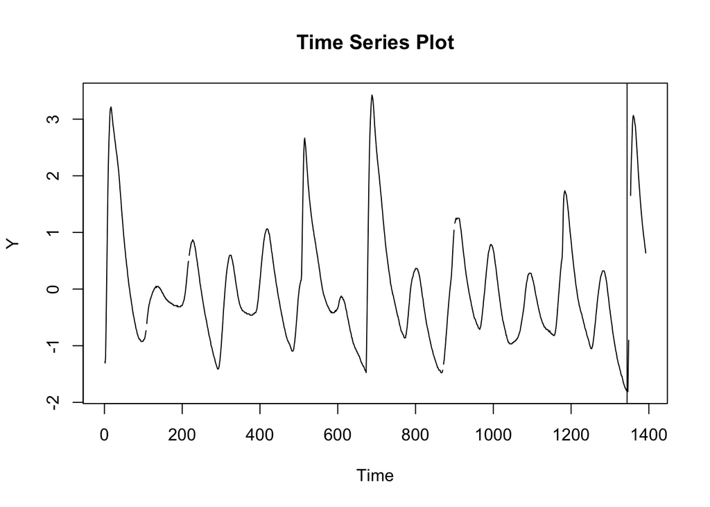

```r
# Load the ggplot2 package
library(ggplot2)

df1 <- read.csv("sensorData/sensor_1.csv")

# Convert the "y" column to a time series object
ts_y <- ts(df1$y)
ts_x <- ts(df1$x)

# Plot the time series
plot.ts(ts_y, main = "Time Series Plot", xlab = "Time", ylab = "Y")
abline(v=1344)
```

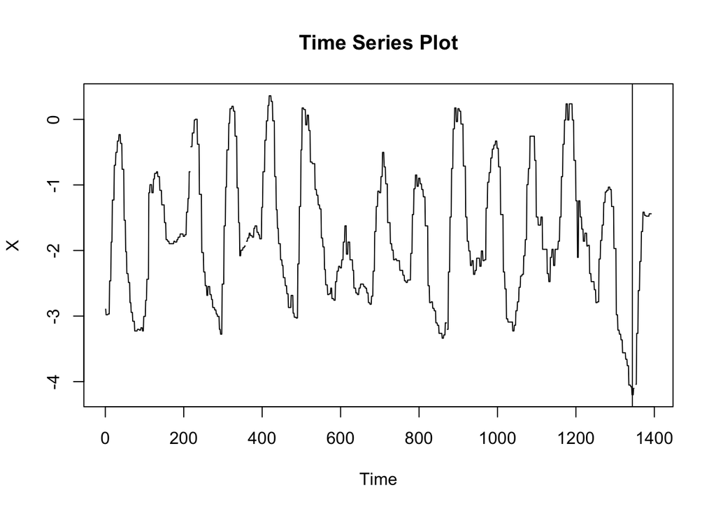

```r
plot.ts(ts_x, main = "Time Series Plot", xlab = "Time", ylab = "X")
abline(v=1344)
```

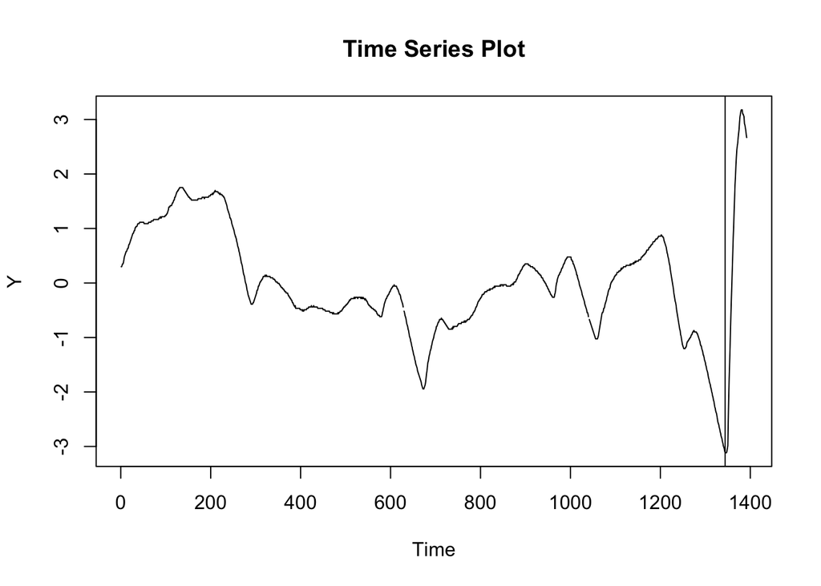

```r
# Load the ggplot2 package
library(ggplot2)

df5 <- read.csv("sensorData/sensor_5.csv")

# Convert the "y" column to a time series object
ts_y5 <- ts(df5$y)
ts_x5 <- ts(df5$x)

# Plot the time series
plot.ts(ts_y5, main = "Time Series Plot", xlab = "Time", ylab = "Y")
abline(v=1344)
```

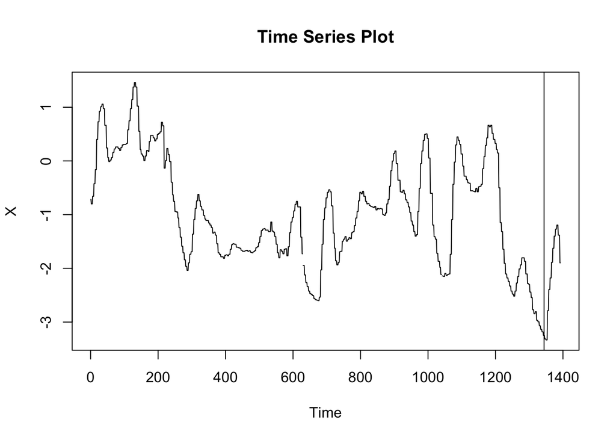

```r
plot.ts(ts_x5, main = "Time Series Plot", xlab = "Time", ylab = "X")
abline(v=1344)
```

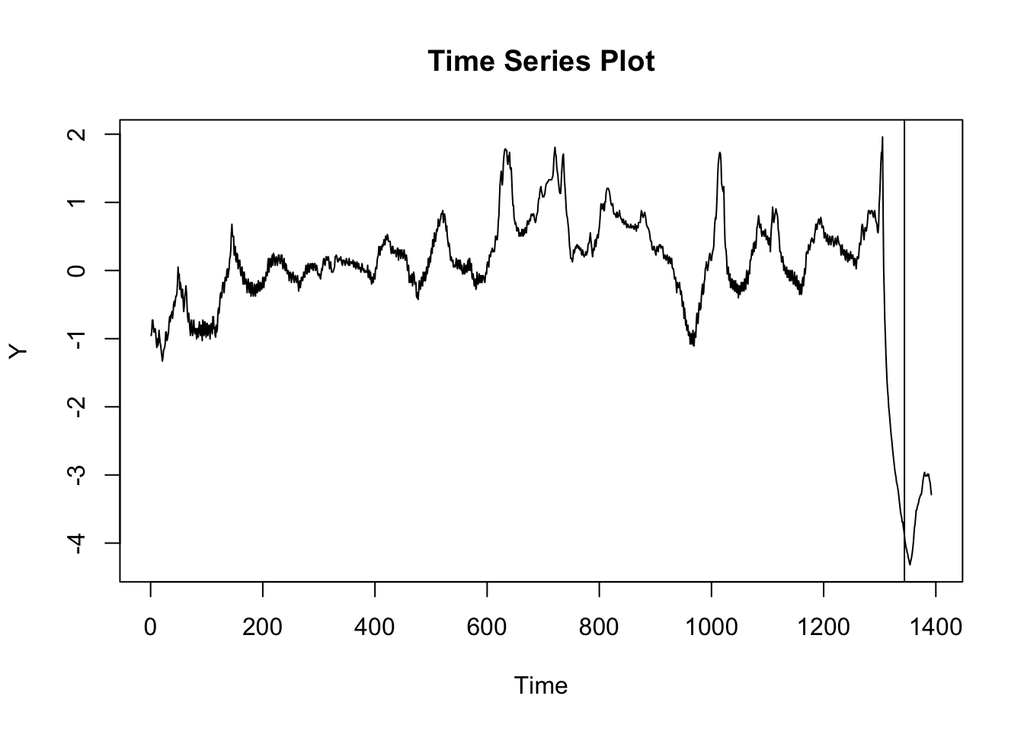

```r
# Load the ggplot2 package
library(ggplot2)

df10 <- read.csv("sensorData/sensor_10.csv")

# Convert the "y" column to a time series object
ts_y10 <- ts(df10$y)
ts_x10 <- ts(df10$x)

# Plot the time series
plot.ts(ts_y10, main = "Time Series Plot", xlab = "Time", ylab = "Y")
abline(v=1344)
```

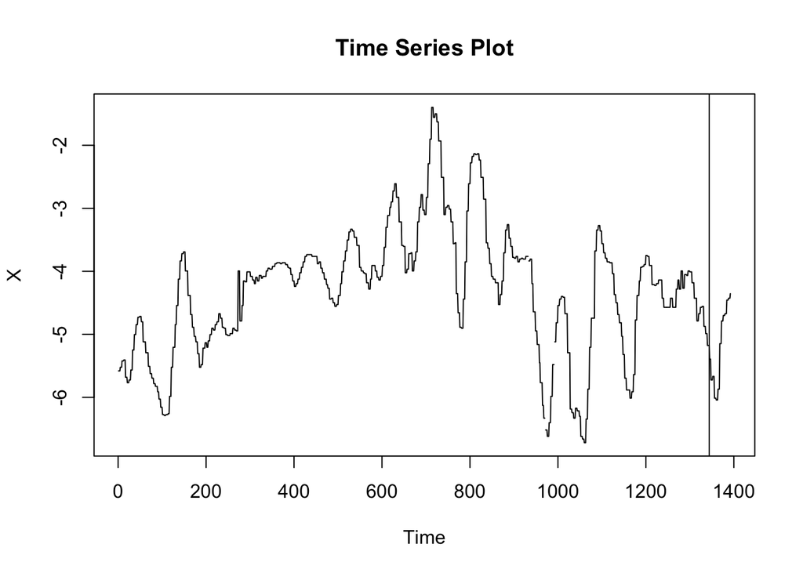

```r
plot.ts(ts_x10, main = "Time Series Plot", xlab = "Time", ylab = "X")
abline(v=1344)
```

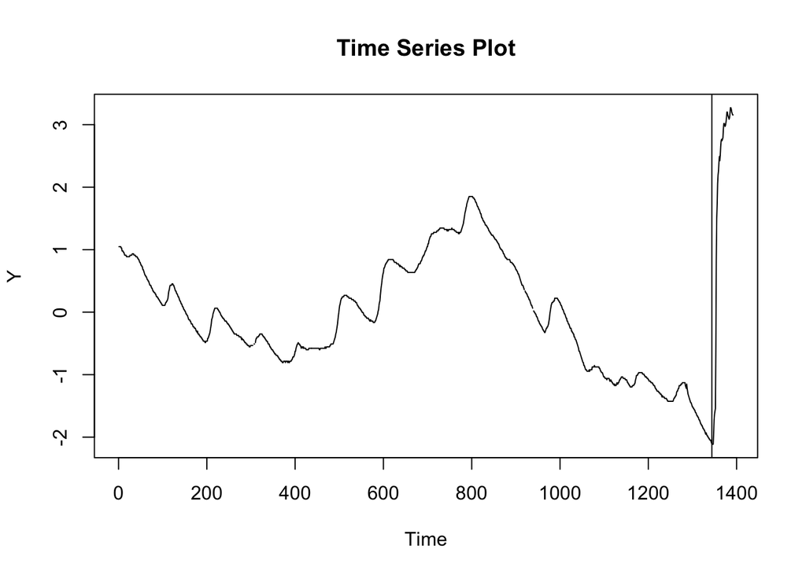

```r
# Load the ggplot2 package
library(ggplot2)

df12 <- read.csv("sensorData/sensor_12.csv")

# Convert the "y" column to a time series object
ts_y12 <- ts(df12$y)
ts_x12 <- ts(df12$x)
# Plot the time series
plot.ts(ts_y12, main = "Time Series Plot", xlab = "Time", ylab = "Y")
abline(v=1344)
```

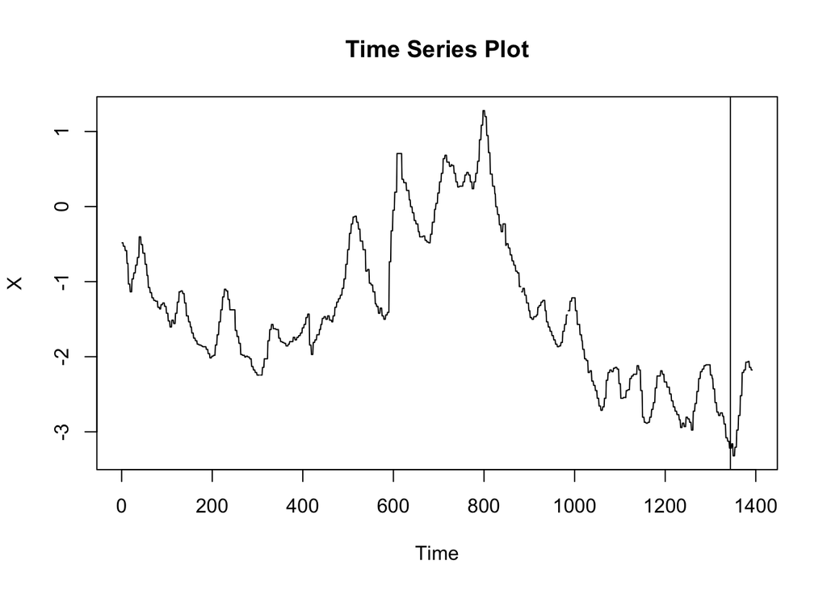

```r
plot.ts(ts_x12, main = "Time Series Plot", xlab = "Time", ylab = "X")
abline(v=1344)
```

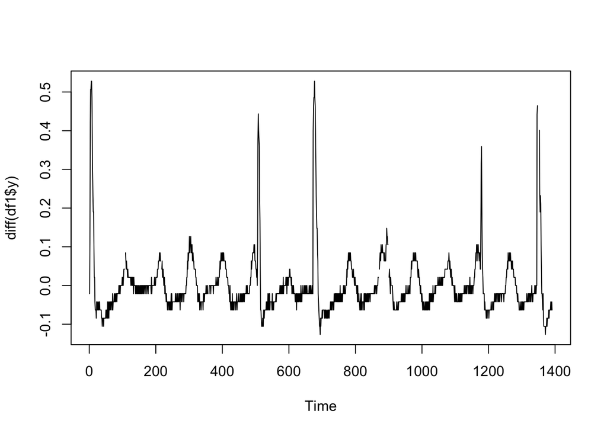

```r
plot.ts(diff(df1$y))
```

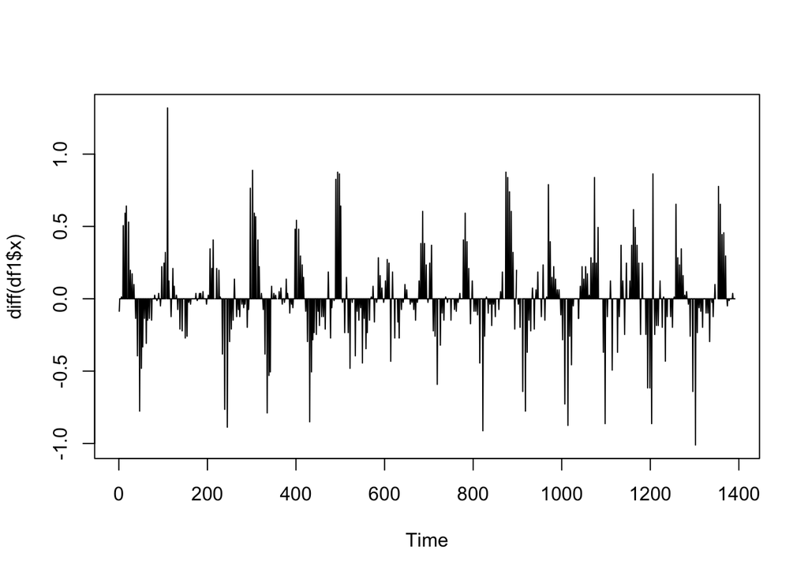

```r
plot.ts(diff(df1$x))
```

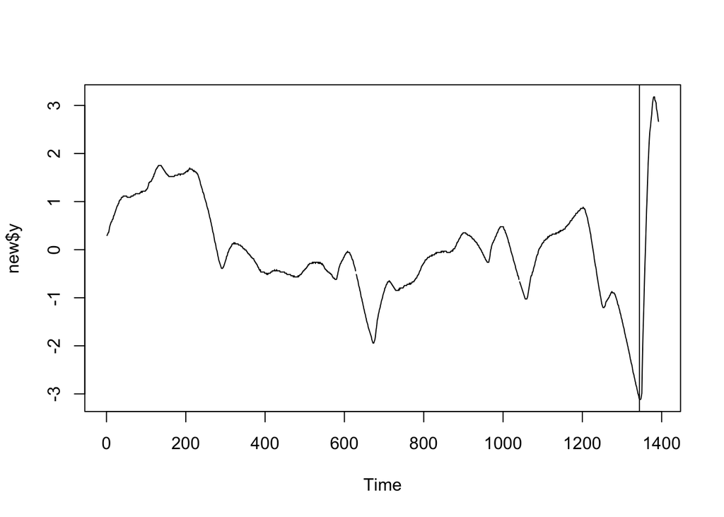

```r
new <- read.csv("sensorData/sensor_5.csv")

plot.ts(new$y)
abline(v=1344)
```

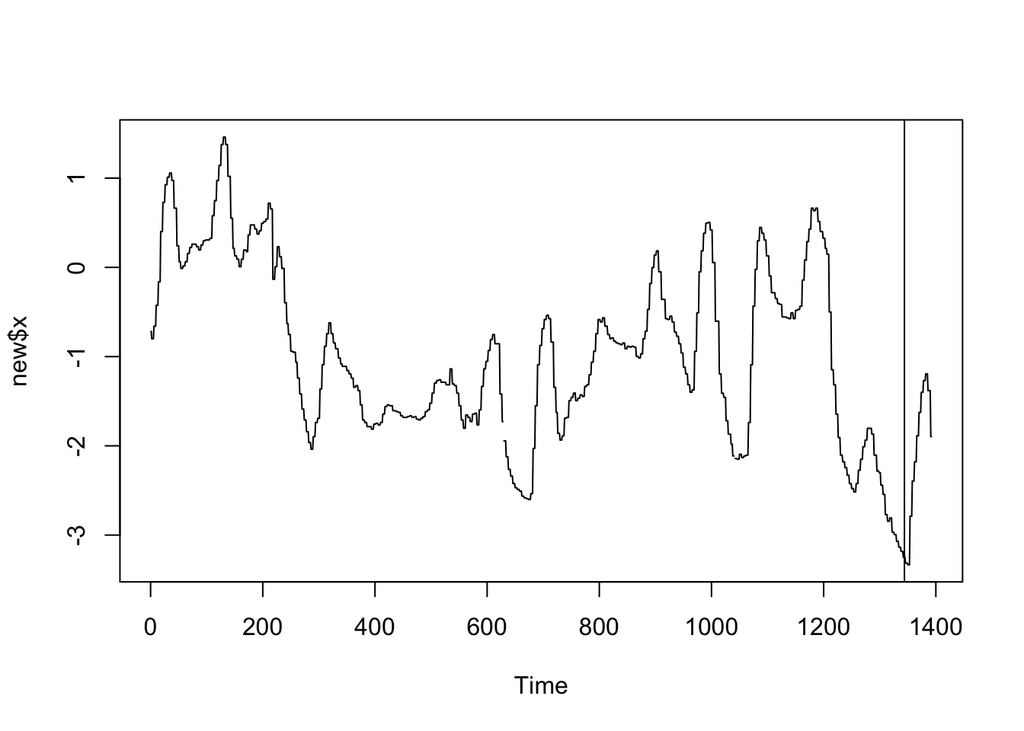

```r
plot.ts(new$x)
abline(v=1344)
```

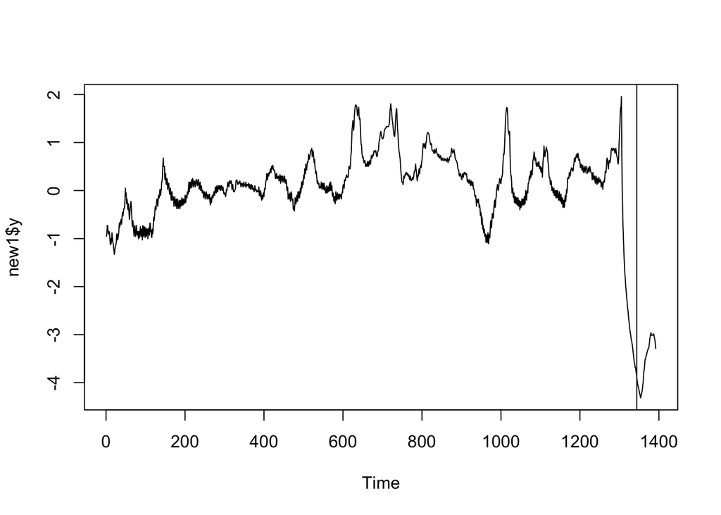

```r
new1 <- read.csv("sensorData/sensor_10.csv")

plot.ts(new1$y)
abline(v=1344)
```

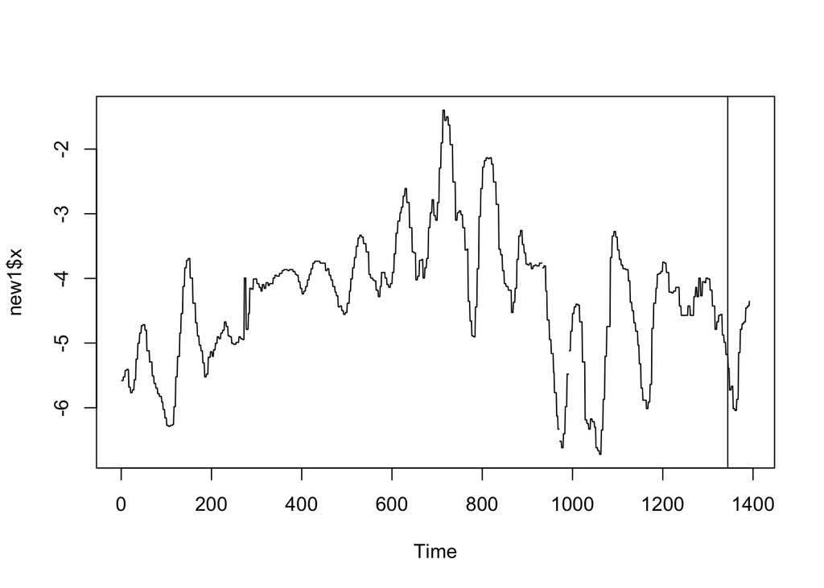

```r
plot.ts(new1$x)
abline(v=1344)
```

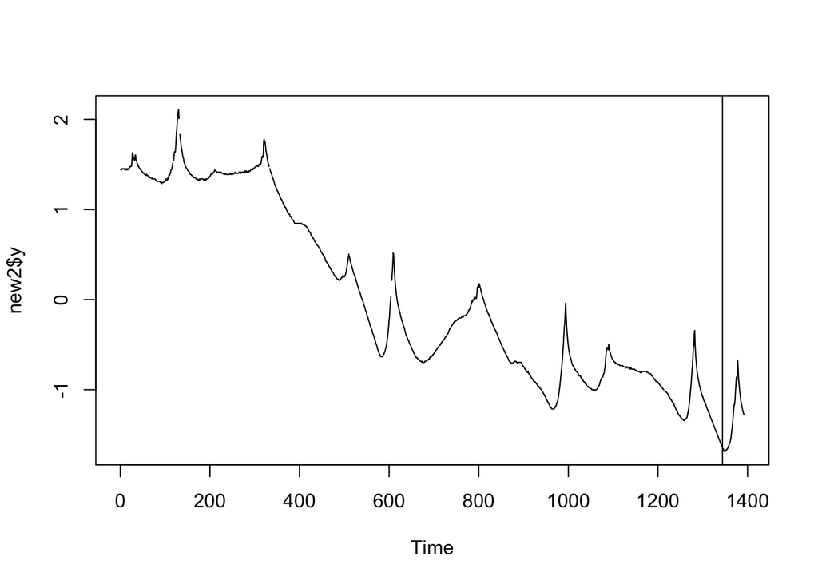

```r
new2 <- read.csv("sensorData/sensor_18.csv")

plot.ts(new2$y)
abline(v=1344)
```

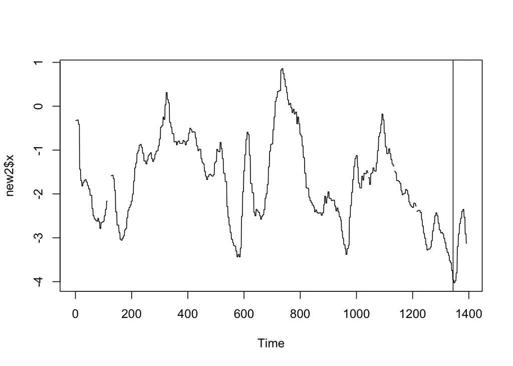

```r
plot.ts(new2$x)
abline(v=1344)
```

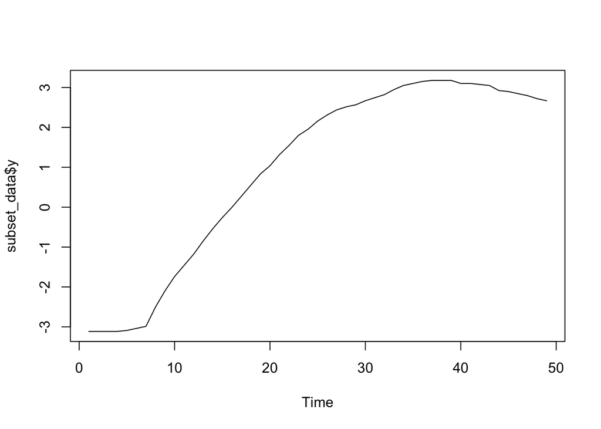

```r
# Read the CSV file
new <- read.csv("sensorData/sensor_5.csv")

# Subset the data for t >= 1344
subset_data <- subset(new, time >= 1344)

# Plot the 'y' variable
plot.ts(subset_data$y)
abline(v = 1344)
```

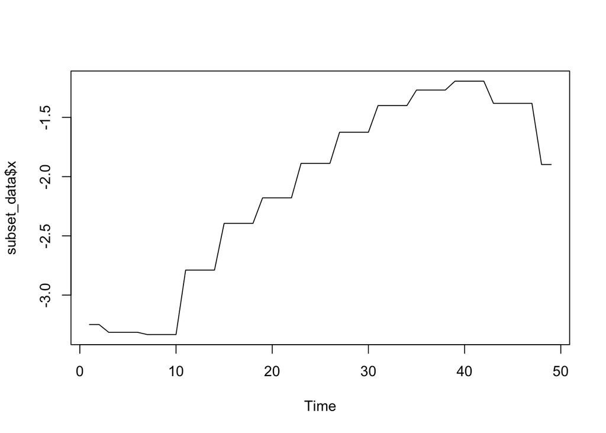

```r
# Plot the 'x' variable
plot.ts(subset_data$x)
abline(v = 1344)
```

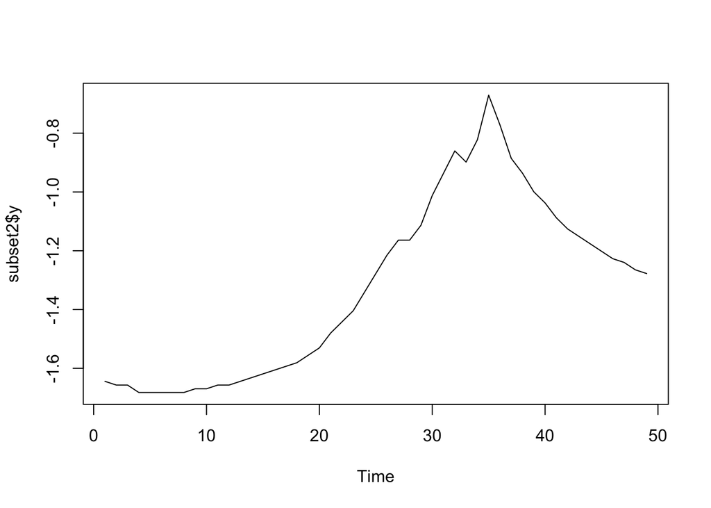

```r
new2S <- read.csv("sensorData/sensor_18.csv")

subset2 <- subset(new2S, time >= 1344)

plot.ts(subset2$y)
abline(v=1344)
```

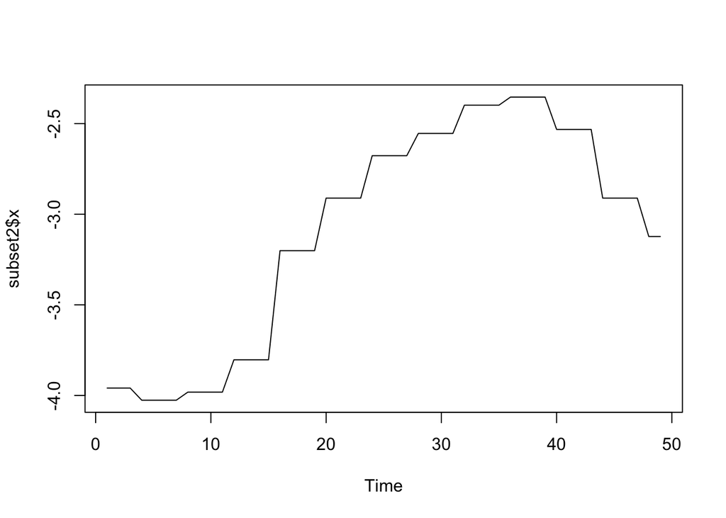

```r
plot.ts(subset2$x)
abline(v=1344)
```

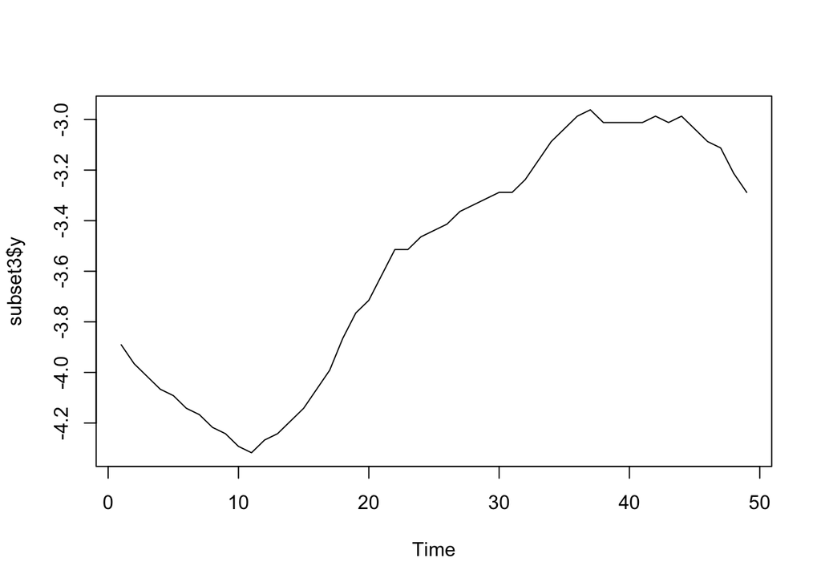

```r
new3S <- read.csv("sensorData/sensor_10.csv")

subset3 <- subset(new3S, time >= 1344)

plot.ts(subset3$y)
abline(v=1344)
```

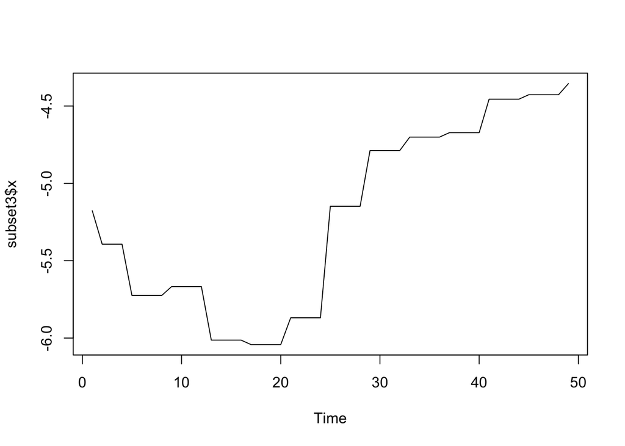

```r
plot.ts(subset3$x)
abline(v=1344)
```

## First Lagged Regression Test

```r
library(tidyverse)
library(tsibble)
library(tidymodels)
library(dplyr)
library(feasts)
library(fable)


df1 <- read.csv("sensorData/sensor_1.csv")
df1$predCol1344 <- ifelse(df1$time >= 1344, 1, 0)
df1$predCol1345 <- ifelse(df1$time >= 1345, 1, 0)
df1$predCol1343 <- ifelse(df1$time >= 1343, 1, 0)
df1$predCol1346 <- ifelse(df1$time >= 1346, 1, 0)
df1$predCol1375 <- ifelse(df1$time >= 1375, 1, 0)


#xDiff <- diff(df1$x)
# Convert the data to tsibble format
df_tsbl1 <- df1 %>%
  as_tsibble(key = sensor, index = time) %>%
  fill_gaps() %>%
  fill(y, x, .direction = "down")

df_split1 <- initial_time_split(df_tsbl1, prop = 96/100)
df_train1 <- training(df_split1)
df_test1 <- testing(df_split1)

model_lags_diff1 <- df_train1 %>%
  mutate(y=c(NA,NA,NA,y[4:1336])) %>%

model(
    lag0 = ARIMA(y ~ x),
    lag1 = ARIMA(y ~ x + lag(x)),
    lag2 = ARIMA(y ~ x + lag(x) + lag(x, 2)),
    lag3 = ARIMA(y ~ x + lag(x) + lag(x, 2) + lag(x, 3)),
    lag4 = ARIMA(y ~ x + lag(x) + lag(x, 2) + lag(x, 3) + lag(x, 4)),
    lag5 = ARIMA(y ~ x + lag(x) + lag(x, 2) + lag(x, 3) + lag(x, 4) + lag(x, 5)),
    lag6 = ARIMA(y ~ x + lag(x) + lag(x, 2) + lag(x, 3) + lag(x, 4) + lag(x, 5) + lag(x, 6)),
    lag7 = ARIMA(y ~ x + lag(x) + lag(x, 2) + lag(x, 3) + lag(x, 4) + lag(x, 5) + lag(x, 6) + lag(x, 7)),
    lag8 = ARIMA(y ~ x + lag(x) + lag(x, 2) + lag(x, 3) + lag(x, 4) + lag(x, 5) + lag(x, 6) + lag(x, 7) + lag(x, 8)),
    lag9 = ARIMA(y ~ x + lag(x) + lag(x, 2) + lag(x, 3) + lag(x, 4) + lag(x, 5) + lag(x, 6) + lag(x, 7) + lag(x, 8) + lag(x, 9)),
    lag10 = ARIMA(y ~ x + lag(x) + lag(x, 2) + lag(x, 3) + lag(x, 4) + lag(x, 5) + lag(x, 6) + lag(x, 7) + lag(x, 8) + lag(x, 9) + lag(x, 10)),
    lag11 = ARIMA(y ~ x + lag(x) + lag(x, 2) + lag(x, 3) + lag(x, 4) + lag(x, 5) + lag(x, 6) + lag(x, 7) + lag(x, 8) + lag(x, 9) + lag(x, 10) +                       lag(x, 11)),
    lag12 = ARIMA(y ~ x + lag(x) + lag(x, 2) + lag(x, 3) + lag(x, 4) + lag(x, 5) + lag(x, 6) + lag(x, 7) + lag(x, 8) + lag(x, 9) + lag(x, 10) +                       lag(x, 11) + lag(x, 12)),
    lag13 = ARIMA(y ~ x + lag(x) + lag(x, 2) + lag(x, 3) + lag(x, 4) + lag(x, 5) + lag(x, 6) + lag(x, 7) + lag(x, 8) + lag(x, 9) + lag(x, 10) +                       lag(x, 11) + lag(x, 12) + lag(x, 13)),
    lag14 = ARIMA(y ~ x + lag(x) + lag(x, 2) + lag(x, 3) + lag(x, 4) + lag(x, 5) + lag(x, 6) + lag(x, 7) + lag(x, 8) + lag(x, 9) + lag(x, 10) +                       lag(x, 11) + lag(x, 12) + lag(x, 13) + lag(x, 14)),
    lag15 = ARIMA(y ~ x + lag(x) + lag(x, 2) + lag(x, 3) + lag(x, 4) + lag(x, 5) + lag(x, 6) + lag(x, 7) + lag(x, 8) + lag(x, 9) + lag(x, 10) +                       lag(x, 11) + lag(x, 12) + lag(x, 13) + lag(x, 14) + lag(x, 15)),
    lag16 = ARIMA(y ~ x + lag(x) + lag(x, 2) + lag(x, 3) + lag(x, 4) + lag(x, 5) + lag(x, 6) + lag(x, 7) + lag(x, 8) + lag(x, 9) + lag(x, 10) +                       lag(x, 11) + lag(x, 12) + lag(x, 13) + lag(x, 14) + lag(x, 15) + lag(x, 16)),
    lag17 = ARIMA(y ~ x + lag(x) + lag(x, 2) + lag(x, 3) + lag(x, 4) + lag(x, 5) + lag(x, 6) + lag(x, 7) + lag(x, 8) + lag(x, 9) + lag(x, 10) +                       lag(x, 11) + lag(x, 12) + lag(x, 13) + lag(x, 14) + lag(x, 15) + lag(x, 16) + lag(x, 17)),
    lag18 = ARIMA(y ~ x + lag(x) + lag(x, 2) + lag(x, 3) + lag(x, 4) + lag(x, 5) + lag(x, 6) + lag(x, 7) + lag(x, 8) + lag(x, 9) + lag(x, 10) +                       lag(x, 11) + lag(x, 12) + lag(x, 13) + lag(x, 14) + lag(x, 15) + lag(x, 16) + lag(x, 17) + lag(x, 18)),
    lag19 = ARIMA(y ~ x + lag(x) + lag(x, 2) + lag(x, 3) + lag(x, 4) + lag(x, 5) + lag(x, 6) + lag(x, 7) + lag(x, 8) + lag(x, 9) + lag(x, 10) +                       lag(x, 11) + lag(x, 12) + lag(x, 13) + lag(x, 14) + lag(x, 15) + lag(x, 16) + lag(x, 17) + lag(x, 18) + lag(x, 19)),
    lag20 = ARIMA(y ~ x + lag(x) + lag(x, 2) + lag(x, 3) + lag(x, 4) + lag(x, 5) + lag(x, 6) + lag(x, 7) + lag(x, 8) + lag(x, 9) + lag(x, 10) +                       lag(x, 11) + lag(x, 12) + lag(x, 13) + lag(x, 14) + lag(x, 15) + lag(x, 16) + lag(x, 17) + lag(x, 18) + lag(x, 19) +                            lag(x, 20))
  )


# View model statistics
glance(model_lags_diff1) %>%
  arrange(AICc) %>%
  select(.model:AICc)
```

```
## # A tibble: 21 × 5
##    .model   sigma2 log_lik    AIC   AICc
##    <chr>     <dbl>   <dbl>  <dbl>  <dbl>
##  1 lag14  0.000660   2965. -5888. -5888.
##  2 lag15  0.000660   2963. -5882. -5881.
##  3 lag16  0.000658   2963. -5879. -5879.
##  4 lag13  0.000668   2959. -5879. -5878.
##  5 lag10  0.000678   2956. -5878. -5878.
##  6 lag11  0.000676   2955. -5874. -5874.
##  7 lag9   0.000683   2953. -5874. -5873.
##  8 lag17  0.000657   2960. -5873. -5872.
##  9 lag12  0.000675   2955. -5871. -5871.
## 10 lag1   0.000708   2942. -5867. -5867.
## # ℹ 11 more rows
```

## Example output for Lagged Regression

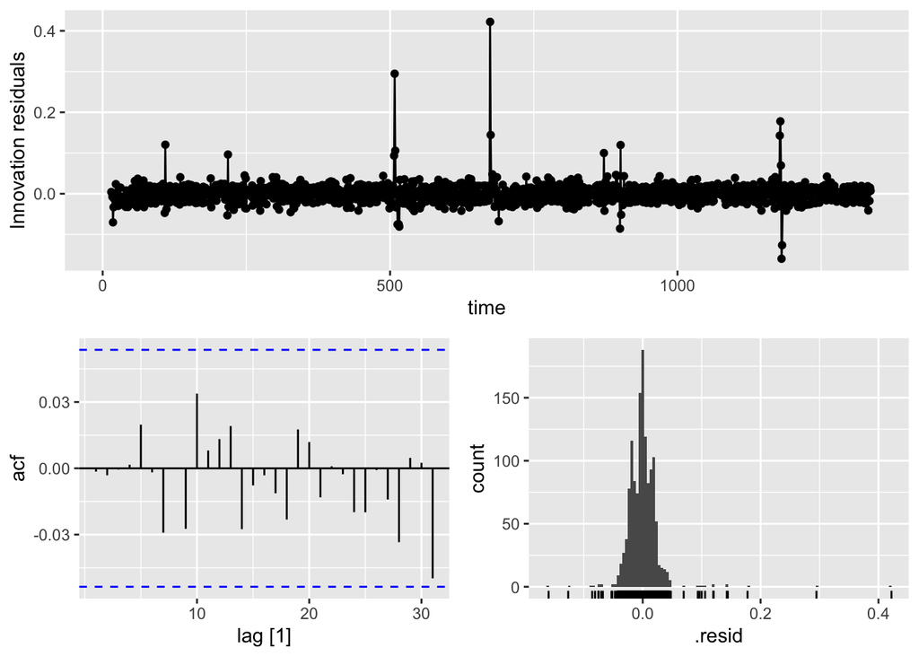

```r
#Creates the model variable to the above results
model_lag10 <- df_train1 %>%
 model(ARIMA(y ~ x + lag(x) + lag(x, 2) + lag(x, 3) + lag(x, 4) + lag(x, 5) + lag(x, 6) + lag(x, 7) + lag(x, 8) + lag(x, 9) + lag(x, 10) +lag(x, 11) + lag(x, 12) + lag(x, 13) + lag(x, 14)))


#Checking the model residuals consistency with white noise

model_lag10 %>% gg_tsresiduals()
```

```r
report(model_lag10)
```

```
## Series: y
## Model: LM w/ ARIMA(5,1,0) errors
##
## Coefficients:
##          ar1     ar2      ar3     ar4      ar5       x  lag(x)  lag(x, 2)
##       0.8048  0.2479  -0.0728  0.0035  -0.1176  0.0043  0.0022     0.0134
## s.e.  0.0273  0.0352   0.0359  0.0353   0.0279  0.0047  0.0063     0.0080
##       lag(x, 3)  lag(x, 4)  lag(x, 5)  lag(x, 6)  lag(x, 7)  lag(x, 8)
##          0.0154     0.0236     0.0290     0.0308     0.0387     0.0351
## s.e.     0.0093     0.0099     0.0101     0.0101     0.0100     0.0099
##       lag(x, 9)  lag(x, 10)  lag(x, 11)  lag(x, 12)  lag(x, 13)  lag(x, 14)
##          0.0431      0.0369      0.0304      0.0282      0.0173      0.0142
## s.e.     0.0097      0.0094      0.0088      0.0077      0.0061      0.0046
##
## sigma^2 estimated as 0.0006595:  log likelihood=2965.16
## AIC=-5888.32   AICc=-5887.62   BIC=-5779.19
```

```r
library(forecast)
library(fabletools)
library(quantmod)
library(TTR)

#Lagged Forecasts
model_pred <- forecast(model_lag10,df_test)
#Accuracy of the lagged model
cor(df_test$y,model_pred$.mean) %>% round(2)

###
# ACC = 0.29
###
```

## Function to Calculate the AICc and Perform Model Selection

```r
library(tidyverse)
library(tsibble)
library(tidymodels)
library(dplyr)
library(feasts)
library(fable)
library(forecast)
library(fabletools)
library(quantmod)
library(TTR)

sensor_analysis <- function(sensor_number) {
  # Read the dataset
  dataset_path <- paste0("sensorData/sensor_", sensor_number, ".csv")
  df <- read.csv(dataset_path)

  # Create prediction columns
  df$predCol1344 <- ifelse(df$time >= 1344, 1, 0)
  df$predCol1345 <- ifelse(df$time >= 1345, 1, 0)
  df$predCol1343 <- ifelse(df$time >= 1343, 1, 0)
  df$predCol1346 <- ifelse(df$time >= 1346, 1, 0)


  # Convert the data to tsibble format
  df_tsbl <- df %>%
    as_tsibble(key = sensor, index = time) %>%
    fill_gaps() %>%
    fill(y, x, .direction = "down")

  # Split the data into training and testing sets
  df_split <- initial_time_split(df_tsbl, prop = 96/100)
  df_train <- training(df_split)
  df_test <- testing(df_split)

  # Build the model with different lags
  model_lags_diff <- df_train %>%
    mutate(y = c(NA, NA, NA, y[4:1336])) %>%
    model(
      lag0 = ARIMA(y ~ x),
      lag1 = ARIMA(y ~ x + lag(x)),
      lag2 = ARIMA(y ~ x + lag(x) + lag(x, 2)),
      lag3 = ARIMA(y ~ x + lag(x) + lag(x, 2) + lag(x, 3)),
      lag4 = ARIMA(y ~ x + lag(x) + lag(x, 2) + lag(x, 3) + lag(x, 4)),
      lag5 = ARIMA(y ~ x + lag(x) + lag(x, 2) + lag(x, 3) + lag(x, 4) + lag(x, 5)),
      lag6 = ARIMA(y ~ x + lag(x) + lag(x, 2) + lag(x, 3) + lag(x, 4) + lag(x, 5) + lag(x, 6)),
      lag7 = ARIMA(y ~ x + lag(x) + lag(x, 2) + lag(x, 3) + lag(x, 4) + lag(x, 5) + lag(x, 6) + lag(x, 7)),
      lag8 = ARIMA(y ~ x + lag(x) + lag(x, 2) + lag(x, 3) + lag(x, 4) + lag(x, 5) + lag(x, 6) + lag(x, 7) + lag(x, 8)),
      lag9 = ARIMA(y ~ x + lag(x) + lag(x, 2) + lag(x, 3) + lag(x, 4) + lag(x, 5) + lag(x, 6) + lag(x, 7) + lag(x, 8) + lag(x, 9)),
      lag10 = ARIMA(y ~ x + lag(x) + lag(x, 2) + lag(x, 3) + lag(x, 4) + lag(x, 5) + lag(x, 6) + lag(x, 7) + lag(x, 8) + lag(x, 9) + lag(x,10)),
      lag11 = ARIMA(y ~ x + lag(x) + lag(x, 2) + lag(x, 3) + lag(x, 4) + lag(x, 5) + lag(x, 6) + lag(x, 7) + lag(x, 8) + lag(x, 9) + lag(x, 10)                     + lag(x, 11)),
      lag12 = ARIMA(y ~ x + lag(x) + lag(x, 2) + lag(x, 3) + lag(x, 4) + lag(x, 5) + lag(x, 6) + lag(x, 7) + lag(x, 8) + lag(x, 9) + lag(x, 10)                     + lag(x, 11) + lag(x, 12)),
      lag13 = ARIMA(y ~ x + lag(x) + lag(x, 2) + lag(x, 3) + lag(x, 4) + lag(x, 5) + lag(x, 6) + lag(x, 7) + lag(x, 8) + lag(x, 9) + lag(x, 10)                     + lag(x, 11) + lag(x, 12) + lag(x, 13)),
      lag14 = ARIMA(y ~ x + lag(x) + lag(x, 2) + lag(x, 3) + lag(x, 4) + lag(x, 5) + lag(x, 6) + lag(x, 7) + lag(x, 8) + lag(x, 9) + lag(x, 10)                     + lag(x, 11) + lag(x, 12) + lag(x, 13) + lag(x, 14)),
      lag15 = ARIMA(y ~ x + lag(x) + lag(x, 2) + lag(x, 3) + lag(x, 4) + lag(x, 5) + lag(x, 6) + lag(x, 7) + lag(x, 8) + lag(x, 9) + lag(x, 10)                     + lag(x, 11) + lag(x, 12) + lag(x, 13) + lag(x, 14) + lag(x, 15)),
      lag16 = ARIMA(y ~ x + lag(x) + lag(x, 2) + lag(x, 3) + lag(x, 4) + lag(x, 5) + lag(x, 6) + lag(x, 7) + lag(x, 8) + lag(x, 9) + lag(x, 10)                     + lag(x, 11) + lag(x, 12) + lag(x, 13) + lag(x, 14) + lag(x, 15) + lag(x, 16)),
      lag17 = ARIMA(y ~ x + lag(x) + lag(x, 2) + lag(x, 3) + lag(x, 4) + lag(x, 5) + lag(x, 6) + lag(x, 7) + lag(x, 8) + lag(x, 9) + lag(x, 10)                     + lag(x, 11) + lag(x, 12) + lag(x, 13) + lag(x, 14) + lag(x, 15) + lag(x, 16) + lag(x, 17)),
      lag18 = ARIMA(y ~ x + lag(x) + lag(x, 2) + lag(x, 3) + lag(x, 4) + lag(x, 5) + lag(x, 6) + lag(x, 7) + lag(x, 8) + lag(x, 9) + lag(x, 10)                     + lag(x, 11) + lag(x, 12) + lag(x, 13) + lag(x, 14) + lag(x, 15) + lag(x, 16) + lag(x, 17) + lag(x, 18)),
      lag19 = ARIMA(y ~ x + lag(x) + lag(x, 2) + lag(x, 3) + lag(x, 4) + lag(x, 5) + lag(x, 6) + lag(x, 7) + lag(x, 8) + lag(x, 9) + lag(x, 10)                     + lag(x, 11) + lag(x, 12) + lag(x, 13) + lag(x, 14) + lag(x, 15) + lag(x, 16) + lag(x, 17) + lag(x, 18) + lag(x, 19)),
      lag20 = ARIMA(y ~ x + lag(x) + lag(x, 2) + lag(x, 3) + lag(x, 4) + lag(x, 5) + lag(x, 6) + lag(x, 7) + lag(x, 8) + lag(x, 9) + lag(x, 10)                     + lag(x, 11) + lag(x, 12) + lag(x, 13) + lag(x, 14) + lag(x, 15) + lag(x, 16) + lag(x, 17) + lag(x, 18) + lag(x, 19)                            + lag(x, 20))
    )

  # View model statistics
  glance(model_lags_diff) %>%
    arrange(AICc) %>%
    select(.model:AICc)
}
```

## Apply Function to Every Subset of dataset

```r
sensor_analysis(1)
```

```
## # A tibble: 21 × 5
##    .model   sigma2 log_lik    AIC   AICc
##    <chr>     <dbl>   <dbl>  <dbl>  <dbl>
##  1 lag14  0.000660   2965. -5888. -5888.
##  2 lag15  0.000660   2963. -5882. -5881.
##  3 lag16  0.000658   2963. -5879. -5879.
##  4 lag13  0.000668   2959. -5879. -5878.
##  5 lag10  0.000678   2956. -5878. -5878.
##  6 lag11  0.000676   2955. -5874. -5874.
##  7 lag9   0.000683   2953. -5874. -5873.
##  8 lag17  0.000657   2960. -5873. -5872.
##  9 lag12  0.000675   2955. -5871. -5871.
## 10 lag1   0.000708   2942. -5867. -5867.
## # ℹ 11 more rows
```

```r
sensor_analysis(2)
```

```
## # A tibble: 21 × 5
##    .model  sigma2 log_lik    AIC   AICc
##    <chr>    <dbl>   <dbl>  <dbl>  <dbl>
##  1 lag12  0.00241   2111. -4188. -4188.
##  2 lag13  0.00241   2110. -4183. -4183.
##  3 lag11  0.00244   2106. -4181. -4180.
##  4 lag10  0.00245   2105. -4181. -4180.
##  5 lag9   0.00246   2104. -4180. -4180.
##  6 lag14  0.00241   2109. -4180. -4179.
##  7 lag15  0.00241   2109. -4175. -4175.
##  8 lag8   0.00248   2100. -4175. -4175.
##  9 lag16  0.00241   2106. -4171. -4170.
## 10 lag6   0.00251   2095. -4168. -4168.
## # ℹ 11 more rows
```

```r
sensor_analysis(3)
```

```
## # A tibble: 21 × 5
##    .model sigma2 log_lik    AIC   AICc
##    <chr>   <dbl>   <dbl>  <dbl>  <dbl>
##  1 lag2   0.0135    977. -1941. -1941.
##  2 lag3   0.0135    978. -1939. -1939.
##  3 lag1   0.0136    975. -1938. -1938.
##  4 lag0   0.0136    974. -1937. -1937.
##  5 lag8   0.0135    976. -1927. -1927.
##  6 lag19  0.0133    975. -1901. -1900.
##  7 lag4   0.0172    817. -1622. -1621.
##  8 lag5   0.0172    816. -1618. -1618.
##  9 lag6   0.0172    815. -1614. -1614.
## 10 lag7   0.0172    814. -1611. -1611.
## # ℹ 11 more rows
```

```r
sensor_analysis(4)
```

```
## # A tibble: 21 × 5
##    .model  sigma2 log_lik    AIC   AICc
##    <chr>    <dbl>   <dbl>  <dbl>  <dbl>
##  1 lag0   0.00465   1689. -3364. -3364.
##  2 lag1   0.00465   1689. -3362. -3362.
##  3 lag2   0.00465   1689. -3360. -3360.
##  4 lag3   0.00465   1689. -3358. -3358.
##  5 lag4   0.00466   1687. -3353. -3353.
##  6 lag5   0.00465   1687. -3350. -3350.
##  7 lag6   0.00465   1686. -3345. -3345.
##  8 lag7   0.00466   1683. -3339. -3339.
##  9 lag8   0.00466   1682. -3336. -3336.
## 10 lag9   0.00466   1681. -3331. -3331.
## # ℹ 11 more rows
```

```r
sensor_analysis(5)
```

```
## # A tibble: 21 × 5
##    .model   sigma2 log_lik    AIC   AICc
##    <chr>     <dbl>   <dbl>  <dbl>  <dbl>
##  1 lag0   0.000214   3739. -7463. -7463.
##  2 lag1   0.000214   3739. -7462. -7462.
##  3 lag2   0.000214   3739. -7461. -7461.
##  4 lag3   0.000214   3740. -7461. -7460.
##  5 lag4   0.000213   3741. -7460. -7460.
##  6 lag5   0.000213   3738. -7452. -7451.
##  7 lag7   0.000211   3738. -7448. -7448.
##  8 lag6   0.000212   3737. -7448. -7448.
##  9 lag8   0.000211   3735. -7441. -7440.
## 10 lag9   0.000211   3732. -7433. -7432.
## # ℹ 11 more rows
```

```r
sensor_analysis(6)
```

```
## # A tibble: 21 × 5
##    .model  sigma2 log_lik    AIC   AICc
##    <chr>    <dbl>   <dbl>  <dbl>  <dbl>
##  1 lag0   0.00316   1943. -3881. -3881.
##  2 lag1   0.00316   1944. -3880. -3880.
##  3 lag2   0.00316   1944. -3878. -3878.
##  4 lag3   0.00316   1944. -3876. -3876.
##  5 lag4   0.00317   1942. -3870. -3870.
##  6 lag5   0.00317   1940. -3865. -3865.
##  7 lag6   0.00317   1939. -3860. -3860.
##  8 lag7   0.00317   1937. -3855. -3855.
##  9 lag8   0.00317   1936. -3849. -3849.
## 10 lag9   0.00317   1934. -3844. -3844.
## # ℹ 11 more rows
```

```r
sensor_analysis(7)
```

```
## # A tibble: 21 × 5
##    .model sigma2 log_lik    AIC   AICc
##    <chr>   <dbl>   <dbl>  <dbl>  <dbl>
##  1 lag0   0.0184    770. -1531. -1531.
##  2 lag1   0.0184    770. -1529. -1529.
##  3 lag2   0.0184    770. -1527. -1527.
##  4 lag3   0.0184    771. -1527. -1527.
##  5 lag4   0.0184    770. -1523. -1523.
##  6 lag5   0.0184    769. -1521. -1521.
##  7 lag6   0.0184    769. -1517. -1517.
##  8 lag7   0.0185    768. -1513. -1513.
##  9 lag9   0.0184    768. -1511. -1511.
## 10 lag8   0.0184    767. -1511. -1510.
## # ℹ 11 more rows
```

```r
sensor_analysis(8)
```

```
## # A tibble: 21 × 5
##    .model   sigma2 log_lik    AIC   AICc
##    <chr>     <dbl>   <dbl>  <dbl>  <dbl>
##  1 lag2   0.000160   3933. -7852. -7852.
##  2 lag3   0.000160   3933. -7850. -7850.
##  3 lag0   0.000161   3928. -7846. -7846.
##  4 lag1   0.000161   3928. -7844. -7844.
##  5 lag4   0.000160   3930. -7842. -7842.
##  6 lag5   0.000159   3931. -7842. -7841.
##  7 lag6   0.000159   3929. -7836. -7836.
##  8 lag7   0.000159   3926. -7829. -7828.
##  9 lag8   0.000159   3923. -7820. -7820.
## 10 lag9   0.000159   3921. -7813. -7813.
## # ℹ 11 more rows
```

```r
sensor_analysis(9)
```

```
## # A tibble: 21 × 5
##    .model  sigma2 log_lik    AIC   AICc
##    <chr>    <dbl>   <dbl>  <dbl>  <dbl>
##  1 lag1   0.00244   2118. -4220. -4220.
##  2 lag0   0.00244   2116. -4218. -4218.
##  3 lag11  0.00238   2122. -4208. -4208.
##  4 lag12  0.00238   2121. -4204. -4204.
##  5 lag9   0.00241   2118. -4203. -4203.
##  6 lag15  0.00238   2116. -4188. -4187.
##  7 lag17  0.00238   2113. -4178. -4177.
##  8 lag18  0.00238   2111. -4173. -4172.
##  9 lag19  0.00238   2109. -4167. -4166.
## 10 lag20  0.00237   2110. -4166. -4165.
## # ℹ 11 more rows
```

```r
sensor_analysis(10)
```

```
## # A tibble: 21 × 5
##    .model  sigma2 log_lik    AIC   AICc
##    <chr>    <dbl>   <dbl>  <dbl>  <dbl>
##  1 lag3   0.00795   1333. -2645. -2645.
##  2 lag4   0.00793   1334. -2645. -2645.
##  3 lag2   0.00797   1330. -2643. -2643.
##  4 lag0   0.00799   1327. -2641. -2641.
##  5 lag5   0.00793   1332. -2640. -2640.
##  6 lag1   0.00799   1328. -2640. -2640.
##  7 lag6   0.00793   1332. -2637. -2637.
##  8 lag7   0.00791   1332. -2636. -2636.
##  9 lag8   0.00791   1331. -2632. -2632.
## 10 lag9   0.00791   1330. -2627. -2627.
## # ℹ 11 more rows
```

```r
sensor_analysis(11)
```

```
## # A tibble: 21 × 5
##    .model   sigma2 log_lik    AIC   AICc
##    <chr>     <dbl>   <dbl>  <dbl>  <dbl>
##  1 lag5   0.000242   3653. -7281. -7281.
##  2 lag6   0.000241   3653. -7280. -7280.
##  3 lag7   0.000240   3652. -7277. -7276.
##  4 lag8   0.000240   3651. -7272. -7271.
##  5 lag9   0.000238   3652. -7272. -7271.
##  6 lag2   0.000247   3643. -7267. -7267.
##  7 lag10  0.000238   3651. -7267. -7267.
##  8 lag11  0.000236   3651. -7266. -7266.
##  9 lag1   0.000248   3641. -7265. -7265.
## 10 lag0   0.000248   3639. -7265. -7265.
## # ℹ 11 more rows
```

```r
sensor_analysis(12)
```

```
## # A tibble: 21 × 5
##    .model   sigma2 log_lik    AIC   AICc
##    <chr>     <dbl>   <dbl>  <dbl>  <dbl>
##  1 lag3   0.000188   3827. -7634. -7634.
##  2 lag4   0.000187   3825. -7629. -7628.
##  3 lag2   0.000189   3823. -7628. -7628.
##  4 lag5   0.000187   3824. -7624. -7624.
##  5 lag0   0.000190   3816. -7619. -7619.
##  6 lag1   0.000190   3817. -7617. -7617.
##  7 lag6   0.000187   3821. -7616. -7616.
##  8 lag7   0.000186   3822. -7616. -7615.
##  9 lag8   0.000186   3819. -7609. -7608.
## 10 lag9   0.000186   3816. -7600. -7600.
## # ℹ 11 more rows
```

```r
sensor_analysis(13)
```

```
## # A tibble: 21 × 5
##    .model  sigma2 log_lik    AIC   AICc
##    <chr>    <dbl>   <dbl>  <dbl>  <dbl>
##  1 lag1   0.00249   2105. -4195. -4195.
##  2 lag0   0.00249   2104. -4194. -4194.
##  3 lag2   0.00249   2106. -4193. -4193.
##  4 lag3   0.00249   2106. -4191. -4191.
##  5 lag4   0.00249   2104. -4186. -4186.
##  6 lag5   0.00249   2102. -4180. -4180.
##  7 lag6   0.00249   2101. -4175. -4175.
##  8 lag7   0.00249   2100. -4171. -4171.
##  9 lag8   0.00249   2098. -4166. -4165.
## 10 lag9   0.00249   2096. -4161. -4160.
## # ℹ 11 more rows
```

```r
sensor_analysis(14)
```

```
## # A tibble: 21 × 5
##    .model   sigma2 log_lik    AIC   AICc
##    <chr>     <dbl>   <dbl>  <dbl>  <dbl>
##  1 lag3   0.000296   3521. -7029. -7029.
##  2 lag1   0.000297   3519. -7028. -7028.
##  3 lag0   0.000297   3518. -7027. -7027.
##  4 lag2   0.000297   3519. -7026. -7026.
##  5 lag4   0.000296   3519. -7023. -7023.
##  6 lag5   0.000296   3516. -7015. -7014.
##  7 lag6   0.000296   3514. -7008. -7008.
##  8 lag7   0.000295   3514. -7007. -7007.
##  9 lag8   0.000294   3515. -7005. -7005.
## 10 lag9   0.000294   3512. -6998. -6998.
## # ℹ 11 more rows
```

```r
sensor_analysis(15)
```

```
## # A tibble: 21 × 5
##    .model  sigma2 log_lik    AIC   AICc
##    <chr>    <dbl>   <dbl>  <dbl>  <dbl>
##  1 lag0   0.00597   1521. -3029. -3029.
##  2 lag1   0.00598   1522. -3027. -3027.
##  3 lag7   0.00591   1525. -3026. -3026.
##  4 lag3   0.00598   1523. -3025. -3025.
##  5 lag2   0.00598   1522. -3025. -3025.
##  6 lag4   0.00598   1521. -3022. -3022.
##  7 lag9   0.00589   1524. -3021. -3021.
##  8 lag8   0.00591   1523. -3021. -3020.
##  9 lag5   0.00598   1519. -3019. -3019.
## 10 lag10  0.00589   1523. -3016. -3016.
## # ℹ 11 more rows
```

```r
sensor_analysis(16)
```

```
## # A tibble: 21 × 5
##    .model   sigma2 log_lik    AIC   AICc
##    <chr>     <dbl>   <dbl>  <dbl>  <dbl>
##  1 lag3   0.000374   3366. -6717. -6717.
##  2 lag0   0.000376   3361. -6713. -6713.
##  3 lag1   0.000377   3361. -6711. -6711.
##  4 lag4   0.000374   3363. -6711. -6710.
##  5 lag2   0.000377   3361. -6710. -6710.
##  6 lag5   0.000375   3360. -6703. -6702.
##  7 lag6   0.000374   3359. -6699. -6699.
##  8 lag7   0.000374   3357. -6692. -6692.
##  9 lag8   0.000374   3354. -6685. -6684.
## 10 lag9   0.000374   3351. -6677. -6677.
## # ℹ 11 more rows
```

```r
sensor_analysis(17)
```

```
## # A tibble: 21 × 5
##    .model  sigma2 log_lik    AIC   AICc
##    <chr>    <dbl>   <dbl>  <dbl>  <dbl>
##  1 lag0   0.00222   2179. -4345. -4345.
##  2 lag5   0.00221   2180. -4344. -4344.
##  3 lag4   0.00222   2179. -4344. -4344.
##  4 lag17  0.00210   2195. -4344. -4343.
##  5 lag9   0.00218   2185. -4341. -4341.
##  6 lag6   0.00221   2179. -4341. -4340.
##  7 lag15  0.00213   2186. -4337. -4336.
##  8 lag3   0.00224   2174. -4335. -4335.
##  9 lag7   0.00221   2177. -4335. -4335.
## 10 lag16  0.00213   2186. -4335. -4334.
## # ℹ 11 more rows
```

```r
sensor_analysis(18)
```

```
## # A tibble: 21 × 5
##    .model   sigma2 log_lik    AIC   AICc
##    <chr>     <dbl>   <dbl>  <dbl>  <dbl>
##  1 lag3   0.000348   3417. -6812. -6811.
##  2 lag5   0.000348   3412. -6798. -6797.
##  3 lag4   0.000351   3408. -6797. -6797.
##  4 lag0   0.000354   3403. -6796. -6796.
##  5 lag1   0.000354   3404. -6795. -6795.
##  6 lag2   0.000353   3404. -6795. -6795.
##  7 lag6   0.000348   3409. -6790. -6789.
##  8 lag7   0.000347   3408. -6787. -6786.
##  9 lag8   0.000347   3406. -6780. -6779.
## 10 lag10  0.000345   3404. -6772. -6772.
## # ℹ 11 more rows
```

```r
sensor_analysis(19)
```

```
## # A tibble: 21 × 5
##    .model  sigma2 log_lik    AIC   AICc
##    <chr>    <dbl>   <dbl>  <dbl>  <dbl>
##  1 lag5   0.00130   2534. -5051. -5051.
##  2 lag0   0.00131   2528. -5051. -5051.
##  3 lag1   0.00131   2529. -5049. -5049.
##  4 lag2   0.00131   2529. -5048. -5048.
##  5 lag3   0.00131   2529. -5047. -5047.
##  6 lag6   0.00130   2532. -5045. -5045.
##  7 lag4   0.00131   2529. -5045. -5045.
##  8 lag7   0.00130   2529. -5039. -5039.
##  9 lag8   0.00130   2527. -5032. -5032.
## 10 lag9   0.00130   2526. -5028. -5027.
## # ℹ 11 more rows
```

```r
sensor_analysis(20)
```

```
## # A tibble: 21 × 5
##    .model sigma2 log_lik    AIC   AICc
##    <chr>   <dbl>   <dbl>  <dbl>  <dbl>
##  1 lag8   0.0210    683. -1336. -1335.
##  2 lag2   0.0215    669. -1325. -1325.
##  3 lag3   0.0215    669. -1324. -1324.
##  4 lag4   0.0215    668. -1321. -1320.
##  5 lag1   0.0216    665. -1320. -1320.
##  6 lag0   0.0216    664. -1320. -1320.
##  7 lag5   0.0215    667. -1317. -1316.
##  8 lag6   0.0215    668. -1315. -1315.
##  9 lag7   0.0215    667. -1311. -1311.
## 10 lag9   0.0214    667. -1308. -1308.
## # ℹ 11 more rows
```

```r
sensor_analysis(21)
```

```
## # A tibble: 21 × 5
##    .model   sigma2 log_lik    AIC   AICc
##    <chr>     <dbl>   <dbl>  <dbl>  <dbl>
##  1 lag9   0.000342   3411. -6795. -6795.
##  2 lag10  0.000340   3413. -6793. -6793.
##  3 lag11  0.000339   3413. -6793. -6793.
##  4 lag12  0.000338   3411. -6788. -6787.
##  5 lag13  0.000337   3412. -6787. -6787.
##  6 lag15  0.000334   3413. -6782. -6782.
##  7 lag14  0.000336   3412. -6781. -6780.
##  8 lag17  0.000331   3413. -6781. -6780.
##  9 lag18  0.000330   3412. -6777. -6776.
## 10 lag16  0.000333   3411. -6777. -6776.
## # ℹ 11 more rows
```

```r
sensor_analysis(22)
```

```
## # A tibble: 21 × 5
##    .model   sigma2 log_lik    AIC   AICc
##    <chr>     <dbl>   <dbl>  <dbl>  <dbl>
##  1 lag0   0.000165   3912. -7810. -7810.
##  2 lag1   0.000165   3912. -7809. -7808.
##  3 lag2   0.000165   3913. -7808. -7808.
##  4 lag3   0.000165   3913. -7806. -7806.
##  5 lag4   0.000165   3912. -7801. -7801.
##  6 lag5   0.000164   3909. -7795. -7795.
##  7 lag6   0.000164   3908. -7790. -7790.
##  8 lag7   0.000164   3905. -7783. -7782.
##  9 lag8   0.000164   3902. -7774. -7774.
## 10 lag10  0.000162   3904. -7773. -7773.
## # ℹ 11 more rows
```

```r
sensor_analysis(23)
```

```
## # A tibble: 21 × 5
##    .model  sigma2 log_lik    AIC   AICc
##    <chr>    <dbl>   <dbl>  <dbl>  <dbl>
##  1 lag6   0.00209   2215. -4404. -4404.
##  2 lag7   0.00209   2214. -4400. -4400.
##  3 lag5   0.00211   2212. -4399. -4399.
##  4 lag3   0.00213   2209. -4397. -4397.
##  5 lag8   0.00209   2214. -4397. -4397.
##  6 lag2   0.00214   2207. -4395. -4395.
##  7 lag1   0.00214   2204. -4393. -4393.
##  8 lag9   0.00209   2212. -4393. -4392.
##  9 lag4   0.00213   2207. -4393. -4392.
## 10 lag0   0.00215   2201. -4388. -4388.
## # ℹ 11 more rows
```

```r
sensor_analysis(24)
```

```
## # A tibble: 21 × 5
##    .model   sigma2 log_lik    AIC   AICc
##    <chr>     <dbl>   <dbl>  <dbl>  <dbl>
##  1 lag3   0.000289   3535. -7051. -7051.
##  2 lag0   0.000293   3528. -7048. -7048.
##  3 lag1   0.000293   3528. -7046. -7046.
##  4 lag2   0.000293   3528. -7044. -7044.
##  5 lag4   0.000293   3523. -7030. -7030.
##  6 lag5   0.000293   3520. -7023. -7023.
##  7 lag6   0.000293   3518. -7016. -7016.
##  8 lag7   0.000293   3515. -7008. -7008.
##  9 lag8   0.000293   3512. -7000. -7000.
## 10 lag9   0.000293   3509. -6992. -6991.
## # ℹ 11 more rows
```

```r
sensor_analysis(25)
```

```
## # A tibble: 21 × 5
##    .model  sigma2 log_lik    AIC   AICc
##    <chr>    <dbl>   <dbl>  <dbl>  <dbl>
##  1 lag0   0.00380   1822. -3634. -3634.
##  2 lag1   0.00380   1822. -3632. -3632.
##  3 lag3   0.00379   1824. -3631. -3631.
##  4 lag2   0.00380   1822. -3631. -3631.
##  5 lag4   0.00379   1822. -3627. -3627.
##  6 lag5   0.00379   1821. -3622. -3622.
##  7 lag6   0.00378   1821. -3620. -3619.
##  8 lag9   0.00375   1821. -3615. -3615.
##  9 lag7   0.00378   1819. -3614. -3614.
## 10 lag8   0.00378   1819. -3611. -3611.
## # ℹ 11 more rows
```

## Modified Function to Calculate the Accuracy Using Correlation, RMSE, MAE, and MAPE

```r
# Calculate RMSE
rmse <- function(actual, predicted) {
  sqrt(mean((actual - predicted)^2))
}

# Calculate MAE
mae <- function(actual, predicted) {
  mean(abs(actual - predicted))
}

# Calculate MAPE
mape <- function(actual, predicted) {
  mean(abs((actual - predicted) / actual)) * 100
}

new_model <- function(sensor_number,optimal) {
  # Read the dataset
  dataset_path <- paste0("sensorData/sensor_", sensor_number, ".csv")
  df <- read.csv(dataset_path)

  # Convert the data to tsibble format
  df_tsbl <- df %>%
    as_tsibble(key = sensor, index = time) %>%
    fill_gaps() %>%
    fill(y, x, .direction = "down")

  # Split the data into training and testing sets
  df_split <- initial_time_split(df_tsbl, prop = 96/100)
  df_train <- training(df_split)
  df_test <- testing(df_split)

  #x <- 0
  if (optimal == 0) {
    x <- ARIMA(y ~ x)
  } else if (optimal == 1) {
    x <- ARIMA(y ~ x + lag(x))
  } else if (optimal == 2) {
    x <- ARIMA(y ~ x + lag(x) + lag(x, 2))
  } else if (optimal == 3) {
    x <- ARIMA(y ~ x + lag(x) + lag(x, 2) + lag(x, 3))
  } else if (optimal == 4) {
    x <- ARIMA(y ~ x + lag(x) + lag(x, 2) + lag(x, 3) + lag(x, 4))
  } else if (optimal == 5) {
    x <- ARIMA(y ~ x + lag(x) + lag(x, 2) + lag(x, 3) + lag(x, 4) + lag(x, 5))
  } else if (optimal == 6) {
    x <- ARIMA(y ~ x + lag(x) + lag(x, 2) + lag(x, 3) + lag(x, 4) + lag(x, 5) + lag(x,6))
  } else if (optimal == 7) {
    x <- ARIMA(y ~ x + lag(x) + lag(x, 2) + lag(x, 3) + lag(x, 4) + lag(x, 5) + lag(x,6) + lag(x,7))
  } else if (optimal == 8) {
    x <- ARIMA(y ~ x + lag(x) + lag(x, 2) + lag(x, 3) + lag(x, 4) + lag(x, 5) + lag(x,6) + lag(x,7) + lag(x,8))
  } else if (optimal == 9) {
    x <- ARIMA(y ~ x + lag(x) + lag(x, 2) + lag(x, 3) + lag(x, 4) + lag(x, 5) + lag(x, 6) + lag(x, 7) + lag(x, 8) + lag(x, 9))
  } else if (optimal == 10) {
    x <- ARIMA(y ~ x + lag(x) + lag(x, 2) + lag(x, 3) + lag(x, 4) + lag(x, 5) + lag(x, 6) + lag(x, 7) + lag(x, 8) + lag(x, 9) + lag(x,10))
  } else if (optimal == 11) {
    x <- ARIMA(y ~ x + lag(x) + lag(x, 2) + lag(x, 3) + lag(x, 4) + lag(x, 5) + lag(x, 6) + lag(x, 7) + lag(x, 8) + lag(x, 9) + lag(x,10) +                    lag(x,11))
  } else if (optimal == 12) {
    x <- ARIMA(y ~ x + lag(x) + lag(x, 2) + lag(x, 3) + lag(x, 4) + lag(x, 5) + lag(x, 6) + lag(x, 7) + lag(x, 8) + lag(x, 9) + lag(x,10) +                    lag(x,11) + lag(x,12))
  } else if (optimal == 13) {
    x <- ARIMA(y ~ x + lag(x) + lag(x, 2) + lag(x, 3) + lag(x, 4) + lag(x, 5) + lag(x, 6) + lag(x, 7) + lag(x, 8) + lag(x, 9) + lag(x,10) +                    lag(x,11) + lag(x,12) + lag(x,13))
  } else if (optimal == 14) {
    x <- ARIMA(y ~ x + lag(x) + lag(x, 2) + lag(x, 3) + lag(x, 4) + lag(x, 5) + lag(x, 6) + lag(x, 7) + lag(x, 8) + lag(x, 9) + lag(x,10) +                    lag(x,11) + lag(x,12) + lag(x,13) + lag(x,14))
  } else if (optimal == 15) {
    x <- ARIMA(y ~ x + lag(x) + lag(x, 2) + lag(x, 3) + lag(x, 4) + lag(x, 5) + lag(x, 6) + lag(x, 7) + lag(x, 8) + lag(x, 9) + lag(x,10) +                    lag(x,11) + lag(x,12) + lag(x,13) + lag(x,14) + lag(x,15))
  } else if (optimal == 16) {
    x <- ARIMA(y ~ x + lag(x) + lag(x, 2) + lag(x, 3) + lag(x, 4) + lag(x, 5) + lag(x, 6) + lag(x, 7) + lag(x, 8) + lag(x, 9) + lag(x,10) +                    lag(x,11) + lag(x,12) + lag(x,13) + lag(x,14) + lag(x,15) + lag(x,16))
  } else if (optimal == 17) {
    x <- ARIMA(y ~ x + lag(x) + lag(x, 2) + lag(x, 3) + lag(x, 4) + lag(x, 5) + lag(x, 6) + lag(x, 7) + lag(x, 8) + lag(x, 9) + lag(x,10) +                    lag(x,11) + lag(x,12) + lag(x,13) + lag(x,14) + lag(x,15) + lag(x,16) + lag(x,17))
  } else if (optimal == 18) {
    x <- ARIMA(y ~ x + lag(x) + lag(x, 2) + lag(x, 3) + lag(x, 4) + lag(x, 5) + lag(x, 6) + lag(x, 7) + lag(x, 8) + lag(x, 9) + lag(x,10) +                    lag(x,11) + lag(x,12) + lag(x,13) + lag(x,14) + lag(x,15) + lag(x,16) + lag(x,17) + lag(x,18))
  } else if (optimal == 19) {
    x <- ARIMA(y ~ x + lag(x) + lag(x, 2) + lag(x, 3) + lag(x, 4) + lag(x, 5) + lag(x, 6) + lag(x, 7) + lag(x, 8) + lag(x, 9) + lag(x,10) +                    lag(x,11) + lag(x,12) + lag(x,13) + lag(x,14) + lag(x,15) + lag(x,16) + lag(x,17) + lag(x,18) + lag(x,19))
  } else if (optimal == 20) {
    x <- ARIMA(y ~ x + lag(x) + lag(x, 2) + lag(x, 3) + lag(x, 4) + lag(x, 5) + lag(x, 6) + lag(x, 7) + lag(x, 8) + lag(x, 9) + lag(x,10) +                    lag(x,11) + lag(x,12) + lag(x,13) + lag(x,14) + lag(x,15) + lag(x,16) + lag(x,17) + lag(x,18) + lag(x,19) + lag(x,20))
  } else if (optimal == 21) {
    x <- ARIMA(y ~ x + lag(x) + lag(x, 2) + lag(x, 3) + lag(x, 4) + lag(x, 5) + lag(x, 6) + lag(x, 7) + lag(x, 8) + lag(x, 9) + lag(x,10) +                    lag(x,11) + lag(x,12) + lag(x,13) + lag(x,14) + lag(x,15) + lag(x,16) + lag(x,17) + lag(x,18) + lag(x,19) + lag(x,20) +                         lag(x,21))
  } else if (optimal == 22) {
    x <- ARIMA(y ~ x + lag(x) + lag(x, 2) + lag(x, 3) + lag(x, 4) + lag(x, 5) + lag(x, 6) + lag(x, 7) + lag(x, 8) + lag(x, 9) + lag(x,10) +                    lag(x,11) + lag(x,12) + lag(x,13) + lag(x,14) + lag(x,15) + lag(x,16) + lag(x,17) + lag(x,18) + lag(x,19) + lag(x,20) +                         lag(x,21) + lag(x,22))
  } else if (optimal == 23) {
    x <- ARIMA(y ~ x + lag(x) + lag(x, 2) + lag(x, 3) + lag(x, 4) + lag(x, 5) + lag(x, 6) + lag(x, 7) + lag(x, 8) + lag(x, 9) + lag(x,10) +                    lag(x,11) + lag(x,12) + lag(x,13) + lag(x,14) + lag(x,15) + lag(x,16) + lag(x,17) + lag(x,18) + lag(x,19) + lag(x,20) +                         lag(x,21) + lag(x,22) + lag(x,23))
  } else if (optimal == 24) {
    x <- ARIMA(y ~ x + lag(x) + lag(x, 2) + lag(x, 3) + lag(x, 4) + lag(x, 5) + lag(x, 6) + lag(x, 7) + lag(x, 8) + lag(x, 9) + lag(x,10) +                    lag(x,11) + lag(x,12) + lag(x,13) + lag(x,14) + lag(x,15) + lag(x,16) + lag(x,17) + lag(x,18) + lag(x,19) + lag(x,20) +                         lag(x,21) + lag(x,22) + lag(x,23) + lag(x,24))
  } else if (optimal == 25) {
    x <- ARIMA(y ~ x + lag(x) + lag(x, 2) + lag(x, 3) + lag(x, 4) + lag(x, 5) + lag(x, 6) + lag(x, 7) + lag(x, 8) + lag(x, 9) + lag(x,10) +                    lag(x,11) + lag(x,12) + lag(x,13) + lag(x,14) + lag(x,15) + lag(x,16) + lag(x,17) + lag(x,18) + lag(x,19) + lag(x,20) +                         lag(x,21) + lag(x,22) + lag(x,23) + lag(x,24) + lag(x,25))
  } else {
    print("Enter valid model number")
  }

  #Creates the model variable to the above results
  model_lag <- df_train %>%
  model(x)

  #Lagged Forecasts
  model_pred <- forecast(model_lag,df_test)
  #Accuracy of the lagged model
  corr <- cor(df_test$y,model_pred$.mean)
  rmse_value <- rmse(df_test$y, model_pred$.mean)
  mae_value <- mae(df_test$y, model_pred$.mean)
  mape_value <- mape(df_test$y, model_pred$.mean)

  return(c(corr,rmse_value,mae_value,mape_value))

}
```

```r
new_model(1,14)
```

```
## [1]   0.2850156   2.8902866   2.3890621 133.1807841
```

```r
new_model(2,12)
```

```
## [1] -0.1985804  0.5186161  0.4732088 20.8518168
```

```r
new_model(3,2)
```

```
## [1]    0.4317807    2.0747828    1.6982856 1510.8063642
```

```r
new_model(4,0)
```

```
## [1]   -0.5727044    1.3670535    1.1634933 1073.2308270
```

```r
new_model(5,0)
```

```
## [1]   -0.9351473    4.6727013    3.8317851 1101.8823363
```

```r
new_model(6,0)
```

```
## [1]  0.6979605  0.3655833  0.3204187 23.7744373
```

```r
new_model(7,0)
```

```
## [1]   0.2397834   1.5898714   1.2315587 284.0233381
```

```r
new_model(8,2)
```

```
## [1]  0.8213864  0.2139970  0.1667468 12.6087802
```

```r
new_model(9,1)
```

```
## [1] 0.8628446 0.1803793 0.1511331 6.3912964
```

```r
new_model(10,3)
```

```
## [1] 0.7244551 0.3871408 0.3489035 9.9190683
```

```r
new_model(11,5)
```

```
## [1] 0.7025885 0.1415618 0.1200196 9.4057180
```

```r
new_model(12,3)
```

```
## [1]  -0.6145417   4.1074746   3.4704062 133.1220172
```

```r
new_model(13,1)
```

```
## [1] -0.2372313  0.7657854  0.4901594 25.8644374
```

```r
new_model(14,3)
```

```
## [1]  -0.1572974   0.7874627   0.4703228 155.1356787
```

```r
new_model(15,0)
```

```
## [1]  -0.4290279   1.2048452   0.9817399 668.6410292
```

```r
new_model(16,3)
```

```
## [1]  0.8820703  0.5006987  0.4551038 43.2512936
```

```r
new_model(17,0)
```

```
## [1]  0.6035457  0.6961931  0.4769033 43.9597054
```

```r
new_model(18,3)
```

```
## [1]  0.7286345  0.3601709  0.2534484 25.0217593
```

```r
new_model(19,5)
```

```
## [1]   0.8773727   0.6033549   0.4873389 183.7186666
```

```r
new_model(20,8)
```

```
## [1]  -0.1330419   0.9788590   0.8349040 218.2972510
```

```r
new_model(21,9)
```

```
## [1]   0.029318   2.978385   2.556157 425.927647
```

```r
new_model(22,0)
```

```
## [1]  -0.6161878   4.7265013   4.0286755 150.6970522
```

```r
new_model(23,6)
```

```
## [1]    0.3651865    1.8310004    1.6175979 3280.8653627
```

```r
new_model(24,3)
```

```
## [1]  -0.07735744   1.16441358   0.74143187 233.33718108
```

```r
new_model(25,0)
```

```
## [1]  -0.5941115   5.2124045   4.3663814 284.1579113
```

```r
corr_ <- c(0.2850156, -0.1985804,0.4317807,-0.5727044,-0.9351473,0.6979605,0.2397834,0.8213864,0.8628446,0.7244551,0.7025885,-0.6145417 ,-0.2372313,-0.1572974,-0.4290279,0.8820703,0.6035457,0.7286345,0.8773727,-0.1330419,0.029318,-0.6161878,0.3651865,-0.07735744,-0.5941115)

rmse_ <- c(2.8902866,0.5186161,2.0747828,1.3670535,4.6727013,0.3655833,1.5898714,0.2139970,0.1803793,0.3871408,0.1415618,4.1074746,0.7657854,0.7874627,1.2048452,0.5006987,0.6961931,0.3601709,0.8773727,0.9788590,2.978385,4.7265013,1.8310004,1.16441358,5.2124045)

mae_ <- c(2.3890621,0.4732088,1.6982856,1.1634933,3.8317851,0.3204187,1.2315587,0.1667468,0.1511331,0.3489035,0.1200196,3.4704062,0.4901594,0.4703228,0.9817399,0.4551038,0.4769033,0.2534484,0.4873389,0.8349040,2.556157,4.0286755,1.6175979,0.74143187,4.3663814)

mape_ <- c(133.1807841,20.8518168,1510.8063642,1073.2308270,1101.8823363,23.7744373,284.0233381,12.6087802,6.3912964,9.9190683,9.4057180,133.1220172,25.8644374,155.1356787,668.6410292,43.2512936,43.9597054,25.0217593,183.7186666,218.2972510,425.927647,150.6970522,3280.8653627,233.33718108,284.1579113)

error_df <- data.frame(sensor=1:25,
                       corr=corr_,
                       rmse=rmse_,
                       mae=mae_,
                       mape=mape_)

error_df
```

[output not shown]

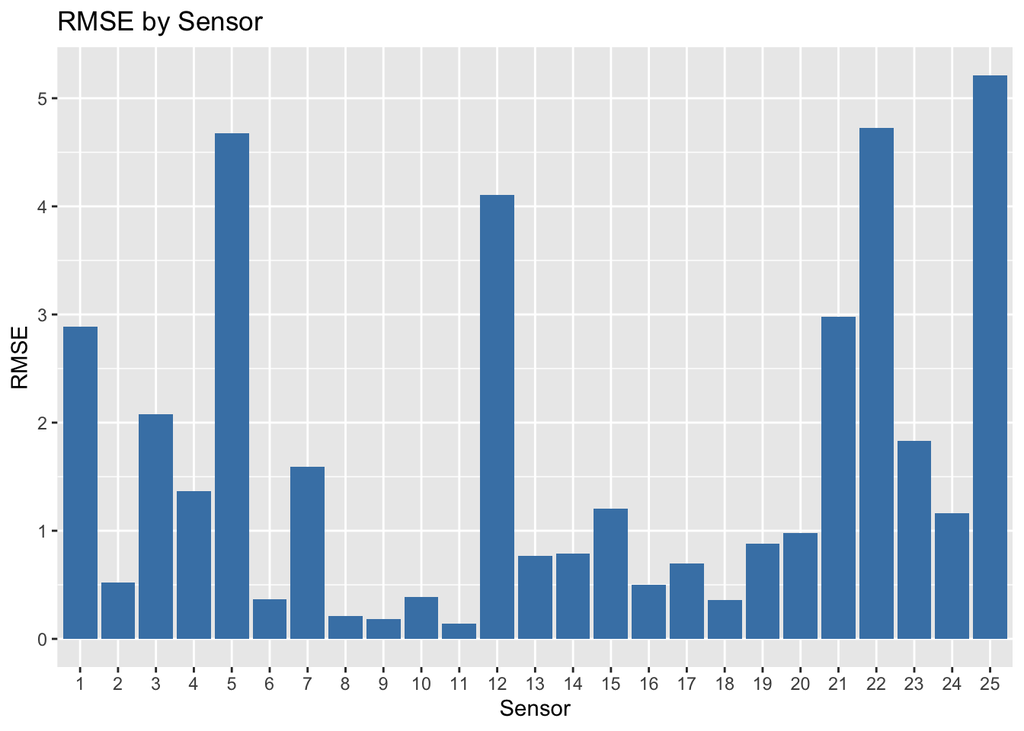

```r
library(ggplot2)

ggplot(error_df, aes(x = factor(sensor), y = rmse)) +
  geom_bar(stat = "identity", fill = "steelblue") +
  labs(x = "Sensor", y = "RMSE") +
  ggtitle("RMSE by Sensor")
```

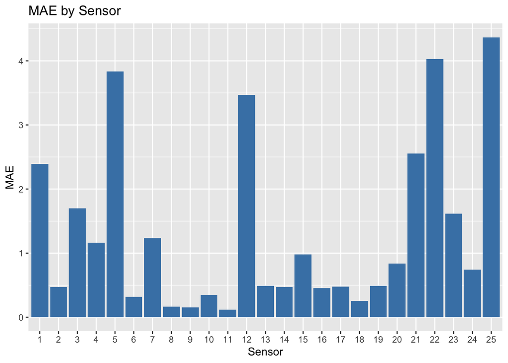

```r
ggplot(error_df, aes(x = factor(sensor), y = mae)) +
  geom_bar(stat = "identity", fill = "steelblue") +
  labs(x = "Sensor", y = "MAE") +
  ggtitle("MAE by Sensor")
```

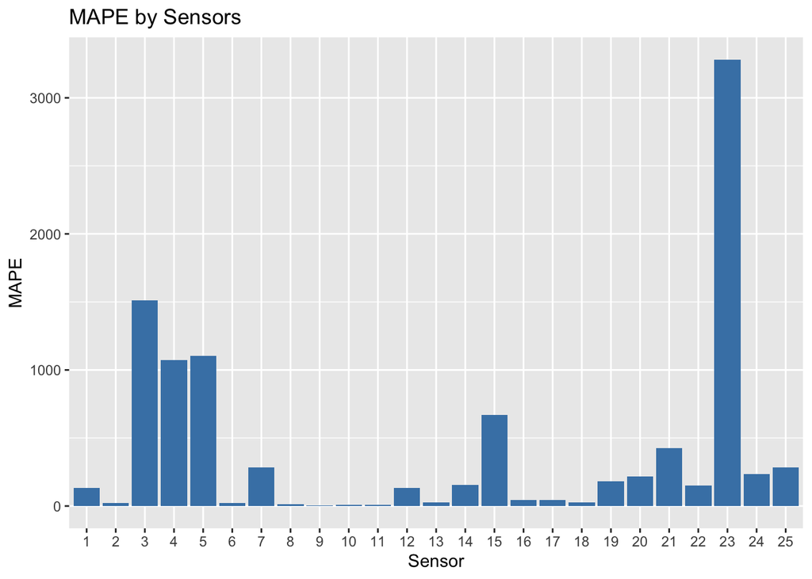

```r
ggplot(error_df, aes(x = factor(sensor), y = mape)) +
  geom_bar(stat = "identity",fill = "steelblue") +
  labs(x = "Sensor", y = "MAPE") +
  ggtitle("MAPE by Sensors")
```

## Analysis

The analysis involved splitting the data into training and testing samples for each sensor. The training samples include the observations from 1 to 1336 which is before the event and the testing sample was the rest of the dataset. Note that the train/test split is done for each of the 25 sensors individually.

The model used is a lagged regression model with a ARMA error given by
$$Y_t = \beta_0 + \beta_1*x_t-1
+\beta_2*x_t-2...\beta_l*x_t-l + \eta_t$$
. The order of the model was selected by the AICc criterion.

Model diagnostics were carried out to determine the adequacy of the model. The fitted model model is used to forecast for the test sample and the accuracy of the forecast was determined using Correlation, RMSE, MAE, and MAPE.

Generally, if there is no action taken after the alert, you expect no structural changes to the time series and the forecast will return a low value of RMSE, MAE, and MAPE. On the other hand, if action is taken, you expect a very high value for each of these metrics as the forecast will fail to properly model the values of the time series after the alert.

Based on the MAE/RMSE we chose cutoffs of the following:

MAE: 1.5 RMSE: 1.5

Meaning that the action was taken after the alerts for the following sensors:

RMSE: 1,3,5,7,12,21,22,23,25

MAE: 1,3,5,12,21,22,23,25

Since 7 is not in both of these metrics the final set is the following:

Action Taken: 1,3,5,12,21,22,23,25